# PowerSeries

## Power Series

Take-aways

After studying this topic, you will be able to

- explain why power series is important,
  - give a few examples where power series is used,
- explain important facts about power series,
  - give several exmaple of power series,
  - explain why it can be thought of a function,
  - explain two different ways to see power series,
- explain the radius of convergence,
  - explain how radius of convergence is power series,
  - explain behaviors of a power series using radius of convergence,
  - give an estimate of radius of convergence from behaviors of power series,

**Remark** (Newton's idea)

[figure not shown]

Newton saw calculus as the algebraic analogue of arithmetic with infinite decimals, and he wrote in his Tractatus de Methodis Serierum et Fluxionum (1671; “Treatise on the Method of Series and Fluxions”):

> I am amazed that it has occurred to no one (if you except N. Mercator and his quadrature of the hyperbola) to fit the doctrine recently established for decimal numbers to variables, especially since the way is then open to more striking consequences. For since this doctrine in species has the same relationship to Algebra that the doctrine of decimal numbers has to common Arithmetic, its operations of Addition, Subtraction, Multiplication, Division and Root extraction may be easily learnt from the latter’s.

Refererence: [Britanica encyclopedia](https://www.britannica.com/topic/Newton-and-Infinite-Series-1368282)

[output not shown]

In fact, power series is very useful.

- Power series provided the first exact formula for $\pi$. ([Leibniz formula (Wikipedia)](https://en.wikipedia.org/wiki/Leibniz_formula_for_%CF%80) We will cover this later.)
- Infinite sequence can be encapsulated by a generating function, which is written in the language of power series. ([Generating function of Fibonacci sequence (Wikipedia)](https://en.wikipedia.org/wiki/Fibonacci_sequence#Generating_function))
- Moment generating function from probability theory is written in the language of power series. ([Moment generating function (Wikipedia)](https://en.wikipedia.org/wiki/Moment-generating_function#Definition))
- Taylor series, which is a basis of numerical analysis, is an example of power series. (We will cover this later.)

Recall geometric series

| $$x$$ | numerical series | sum |
| --- | --- | --- |
| $$\frac 1 2$$ | $$1 + {\frac 1 2} + ({\frac 1 2})^2 +\cdots$$ | 2 |
| $$\frac 2 3$$ | $$1 + {\frac 2 3} + ({\frac 2 3})^2 +\cdots$$ | 3 |
| $$-1 < x < 1$$ | $$1 + {x} + {x}^2 +\cdots$$ | $$\frac{1}{1-x}$$ |

Now, make the geometric series more versatile.

> **Definition** (Power series)

> For a given sequence $\{a_n\}_{n=0}^\infty$, the infinite sum $$\sum_{n=0}^\infty a_n x^n$$ is called *power series*. The sequence $\{a_n\}_{n=0}^\infty$ is called the *coefficients* of the series.

> **Example**

> The geometric series is an example of power series. $$1 + {x} + {x}^2 +\cdots$$

> What are the coefficients?

> **Example**

> The following is another example of power series. $$1 + 2{x} + 3{x}^2 + \cdots+ (n+1)x^n +\cdots$$

> What are the coefficients?

> **Example**

> The following is another example of power series, called Bessel function of order 0. $$\sum_{n=0}^{\infty} \frac{(-1)^n x^{2 n}}{2^{2 n}(n !)^2}$$

> What are the coefficients?

> **Question**

> Give three examples of power series.

> **Fact 1**

> A power series is a function.

**Approach 1 to Fact 1**

- Every time you change $x$, you have a different infinite sum. --> Function.

**Approach 2 to Fact 1**

- For example, *Partial sums* $1$, $1+x$, $1+x+\frac{x^2}{2!}$, $1+x+\frac{x^2}{2!}+\frac{x^3}{3!}$, $\cdots$ behave more and more similarly to a specific function, in this case $e^x$.
- We can imagine that if we add infinitely many of them, that will behave exactly the same as $e^x$.
- Again, a power series can be seen as a function as an infinite sum of functions.

[figure not shown]

[Interactive Geogebra](https://www.geogebra.org/m/YtnuMjEF)

Geogebra activity suggestion

- Type in a simple function such as $e^x$, $1/(1-x)$, $\sin(x)$, etc.
- Move the slide bar to vary $n$.

> **Question**

> What would you name this object, if you found this for the first time?

> **Example** (Bessel function revisited)

> If it is a really a function, we can graph it. $$\sum_{n=0}^{\infty} \frac{(-1)^n x^{2 n}}{2^{2 n}(n !)^2}$$

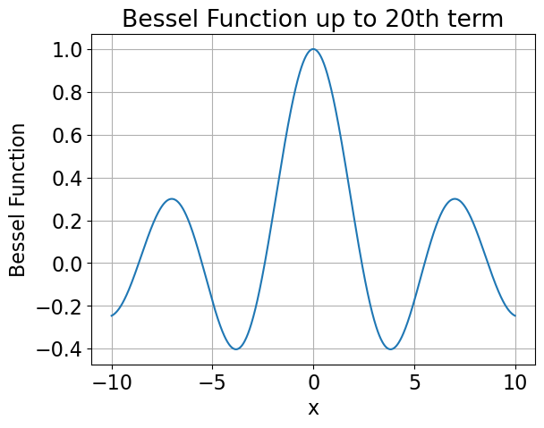

```
(1000,)
```

```python
import numpy as np
import scipy
import matplotlib.pyplot as plt
plt.rcParams.update({'font.size': 16})

x = np.linspace(-10, 10, 1000)  # Range of x values
N = 20  # Number of terms
n = np.arange(N+1)
a_n = (-1)**n / (scipy.special.factorial(n)**2 * 2**(2*n))
x_n = x.reshape((-1,1))**(2*n)

# Calculate the Bessel function up to the 10th term
y = x_n @ a_n

# Plot the Bessel function
plt.plot(x, y)
plt.xlabel('x')
plt.ylabel('Bessel Function')
plt.title(f'Bessel Function up to {N}th term')
plt.grid(True)
plt.show()

print(y.shape)
```

### Radius of convergence

```
     x       a_n = 1  b_n = 1/n!
0 -2.0  1.358024e+90    0.135335
1 -1.5  4.032078e+52    0.223130
2 -0.9  5.263158e-01    0.406570
3  0.0  1.000000e+00    1.000000
4  0.8  5.000000e+00    2.225541
5  1.4  2.412563e+44    4.055200
6  2.0  4.074072e+90    7.389056
```

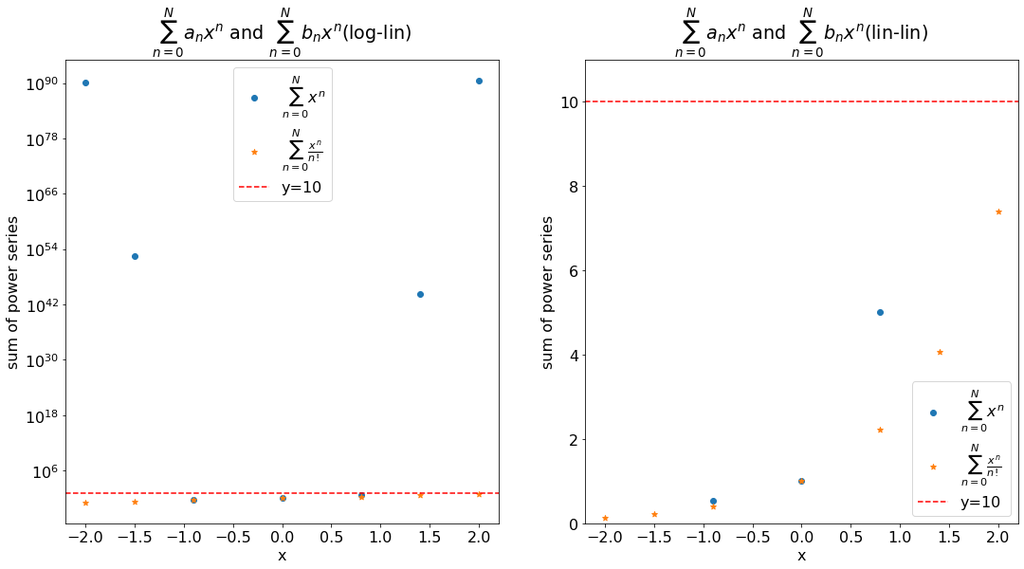

```python
import numpy as np
import scipy
import pandas as pd
import matplotlib.pyplot as plt
plt.rcParams.update({'font.size': 16})

x = np.array([-2, -1.5, -0.9, 0, 0.8, 1.4, 2])  # Range of x values
N = 300  # Number of terms
n = np.arange(N+1)
a_n = 1.0 * np.ones_like(n) # a_n = 1
b_n = 1.0 / scipy.special.factorial(n) # b_n = 1/n!

x_n = x.reshape((-1,1))**(n)

# Calculate the partial sum up to N terms
y = x_n @ a_n # y = sum(a_n * x^n)
z = x_n @ b_n # z = sum(b_n * x^n)

# report the results
df = pd.DataFrame({'x': x, 'a_n = 1': y, 'b_n = 1/n!': z})
print(df)

# Plot
fig, ax = plt.subplots(1,2, figsize=(18, 9))

for i in range(len(ax)):
    # Plot y and z against x with log-linear scale
    ax[i].scatter(x, y, label=r'$\sum_{n=0}^{N} x^n$', marker='o')
    ax[i].scatter(x, z, label=r'$\sum_{n=0}^{N} \frac{x^n}{n!}$', marker='*')

    # Set labels
    ax[i].set_xlabel('x')
    ax[i].set_ylabel('sum of power series')

    # horizontal line for some reasonable values: y=10
    ax[i].axhline(y=10, color='red', linestyle='--', label='y=10')

    # Show legend
    ax[i].legend()

# Set log scale for y-axis
ax[0].set_yscale('log')
ax[1].set_ylim([0, 11])

# Set the title
ax[0].set_title(r'$\sum_{n=0}^{N} a_n x^n$ and $\sum_{n=0}^{N} b_n x^n$(log-lin)')
ax[1].set_title(r'$\sum_{n=0}^{N} a_n x^n$ and $\sum_{n=0}^{N} b_n x^n$(lin-lin)')



# Show the plot
plt.show()
```

> **Fact 2** (Radius of convergence)

> Each power series $\sum_{n=0}^{\infty} a_n x^n$ is associated a number $R$, the *raduis of convergence*, and the only one of the following is true:
> 1. $R=0$ and $\sum_{n=0}^{\infty} a_n x^n$ has finite value only when $x=0$ and diverges for all other values.
> 2. $0 < R < \infty$ and $\sum_{n=0}^{\infty} a_n x^n$
>    - converges to a finite value if $-R < x < R$,
>    - diverges if $x < -R$ or $x > R$,
>    - converges or diverges at $x=R$ and $x=-R$. (depends on $a_n$'s)
> 3. $R=\infty$ and $\sum_{n=0}^{\infty} a_n x^n$ always converges to a finite value for any $x\in \mathbb{R}$.

> **Remark** (Consequence of the existence of radius of convergence)
> - If, for example, $\sum_{n=0}^{\infty} a_n 4^n$ converges, we must have $R \ge 4$. (Why?)
> - If, for example, $\sum_{n=0}^{\infty} a_n (-3)^n$ diverges, we must have $R \le 3$. (Why?)

> **Example** (Estimate radius of convergence from behaviors of power series)
> 1. Does $\sum_{n=0}^{\infty} x^n$ (i.e., $a_n = 1$ for all $n \ge 0$) converge at $x=1$?
> 2. Does $\sum_{n=0}^{\infty} x^n$ (i.e., $a_n = 1$ for all $n \ge 0$) converge at $x=0.9$? What about at $x=0.99$?
> 3. Give a good guess on the radius of convergence of $\sum_{n=0}^{\infty} x^n$?
> 4. Can $\sum_{n=0}^{\infty} (-0.3)^n$ diverge?
> 5. Can $\sum_{n=0}^{\infty} x^n$ have another radius of convergen?

> **Example** (Behavior of power series from radius of convergence)

> In fact, we can show the radius of convergence of Bessel function $$\sum_{n=0}^{\infty} \frac{(-1)^n x^{2 n}}{2^{2 n}(n !)^2}$$ is $R=\infty$.
> 1. Can you choose a very big number, say, $x=10^{1000}$ to make $\sum_{n=0}^{\infty} \frac{(-1)^n x^{2 n}}{2^{2 n}(n !)^2}$ diverge?

> **Question**

> Can you come up with a power series that has 0 radius of convergence?

> **Remark** (Why radius of convergence matters?)

> As mentioned earlier, power series can be used for many useful tasks. However, they can be used only when they have reasonable output, i.e., when they converge.

> **Next lecture**
> - Learn how to find radius of convergence.
> - How to find a power series that helps study a specific function of interest: Taylor series.